# NYC Shooting Information

Student

2025-07-08

# Project Requirements

Import, tidy and analyze the NYPD Shooting Incident dataset obtained. Be sure your project is reproducible and contains some visualization and analysis. You may use the data to do any analysis that is of interest to you. You should include at least two visualizations and one model. Be sure to identify any bias possible in the data and in your analysis.

All code will be present in document, but placed in the ‘show’ button to keep the document and visualizations cleaner. There is also a ‘Code’ drop down in the upper right hand corner of the document that you can choose to show all or hide all code if helpful.

# Import the Data

Below is a summary of the data we will be using. The data is a list of every shooting incident that occurred in NYC going back to 2006 through the end of the previous calendar year (2024).

```r
library(lubridate)
library(ggplot2)
library(tidyverse)

url_in <- 'https://data.cityofnewyork.us/api/views/833y-fsy8/rows.csv?accessType=DOWNLOAD'

shooting <- read_csv(url_in)

summary(shooting)
```

```
##   INCIDENT_KEY        OCCUR_DATE          OCCUR_TIME
##  Min.   :  9953245   Length:29744       Min.   :00:00:00.000000
##  1st Qu.: 67321140   Class :character   1st Qu.:03:30:45.000000
##  Median :109291972   Mode  :character   Median :15:15:00.000000
##  Mean   :133850951                      Mean   :12:46:10.874798
##  3rd Qu.:214741917                      3rd Qu.:20:44:00.000000
##  Max.   :299462478                      Max.   :23:59:00.000000
##
##      BORO           LOC_OF_OCCUR_DESC     PRECINCT      JURISDICTION_CODE
##  Length:29744       Length:29744       Min.   :  1.00   Min.   :0.0000
##  Class :character   Class :character   1st Qu.: 44.00   1st Qu.:0.0000
##  Mode  :character   Mode  :character   Median : 67.00   Median :0.0000
##                                        Mean   : 65.23   Mean   :0.3181
##                                        3rd Qu.: 81.00   3rd Qu.:0.0000
##                                        Max.   :123.00   Max.   :2.0000
##                                                         NA's   :2
##  LOC_CLASSFCTN_DESC LOCATION_DESC      STATISTICAL_MURDER_FLAG
##  Length:29744       Length:29744       Mode :logical
##  Class :character   Class :character   FALSE:23979
##  Mode  :character   Mode  :character   TRUE :5765
##
##
##
##
##  PERP_AGE_GROUP       PERP_SEX          PERP_RACE         VIC_AGE_GROUP
##  Length:29744       Length:29744       Length:29744       Length:29744
##  Class :character   Class :character   Class :character   Class :character
##  Mode  :character   Mode  :character   Mode  :character   Mode  :character
##
##
##
##
##    VIC_SEX            VIC_RACE           X_COORD_CD        Y_COORD_CD
##  Length:29744       Length:29744       Min.   : 914928   Min.   :125757
##  Class :character   Class :character   1st Qu.:1000094   1st Qu.:183042
##  Mode  :character   Mode  :character   Median :1007826   Median :195506
##                                        Mean   :1009442   Mean   :208722
##                                        3rd Qu.:1016739   3rd Qu.:239980
##                                        Max.   :1066815   Max.   :271128
##
##     Latitude       Longitude        Lon_Lat
##  Min.   :40.51   Min.   :-74.25   Length:29744
##  1st Qu.:40.67   1st Qu.:-73.94   Class :character
##  Median :40.70   Median :-73.91   Mode  :character
##  Mean   :40.74   Mean   :-73.91
##  3rd Qu.:40.83   3rd Qu.:-73.88
##  Max.   :40.91   Max.   :-73.70
##  NA's   :97      NA's   :97
```

# Tidy and Transform the Data

The code below transforms data (e.g., factoritization of data) as well as adds some variables I would like to segement out and review (e.g., hour and day of week variables).

```r
shooting_trans <- shooting %>%
  mutate(OCCUR_DATE = mdy(OCCUR_DATE),
         BORO = as.factor(BORO),
         LOC_OF_OCCUR_DESC = as.factor(LOC_OF_OCCUR_DESC),
         PRECINCT = as.factor(PRECINCT),
         JURISDICTION_CODE = as.factor(JURISDICTION_CODE),
         PERP_AGE_GROUP = as.factor(PERP_AGE_GROUP),
         PERP_SEX = as.factor(PERP_SEX),
         PERP_RACE = as.factor(PERP_RACE),
         VIC_AGE_GROUP = as.factor(VIC_AGE_GROUP),
         VIC_SEX = as.factor(VIC_SEX),
         VIC_RACE = as.factor(VIC_RACE))

# Data Dictionary Information:
#   Jurisdiction where the shooting incident occurred.
#   Jurisdiction codes 0(Patrol), 1(Transit) and 2(Housing)
#   represent NYPD whilst codes 3 and more represent non NYPD jurisdictions
# Rename levels
levels(shooting_trans$JURISDICTION_CODE) <- list(Patrol = "0",
                                                     Transit = "1",
                                                     Housing = "2")

# add some date options
shooting_trans <- shooting_trans %>%
  mutate(year = year(OCCUR_DATE),
         month = month(OCCUR_DATE),
         quarter = quarter(OCCUR_DATE),
         day_of_week = wday(OCCUR_DATE)) # 1 = Sunday

# based on analysis, I believe there to be non-continous trends on year
shooting_trans <- shooting_trans %>%
  mutate(year = as.factor(year),
         month = as.factor(month),
         quarter = as.factor(quarter),
         day_of_week = as.factor(day_of_week))

# Rename levels
levels(shooting_trans$day_of_week) <- list(Sunday = "1",
                                           Monday = "2",
                                           Tuesday = "3",
                                           Wednesday = "4",
                                           Thursday = "5",
                                           Friday = "6",
                                           Saturday = "7")

# based on analysis - summer seems to have increased incidents
# (may be more helpful than quarter)
shooting_trans <- shooting_trans %>%
  mutate(is_summer = case_when(month %in% c(6,7,8) ~ TRUE,
                               .default = FALSE),
         is_fall = case_when(month %in% c(9,10,11,12) ~ TRUE,
                             .default = FALSE),
         is_winterspring = case_when(month %in% c(1, 2, 3, 4, 5) ~ TRUE,
                                     .default = FALSE),
         season = case_when(month %in% c(6,7,8) ~ "summer",
                            month %in% c(9,10,11,12) ~ "fall",
                            month %in% c(1, 2, 3, 4, 5) ~ "winterspring"))


# generalize time a bit
shooting_trans <- shooting_trans %>%
  mutate(hour = hour(OCCUR_TIME))
```

# Analyze the Data

I took several different cuts at the data attempting to see if there was anything interesting or missing in the data. These cuts (and the subsequent prettier versions I will share in Visualizations) helped me determine what I thought could be modeled for an interesting prediction set and gave me clues as to what would not be helpful. For instance, many of the perpetrator demographic fields were not very complete. Additionally, it helped to cut several of the time variables up into more descrete pieces (done in the Transformation section subequent to analysis).

```r
shooting_trans %>%
  group_by(BORO) %>%
  summarise(shooting_cnt = n(),
            murder_cnt = sum(STATISTICAL_MURDER_FLAG)) %>%
  ungroup() %>%
  mutate(murder_pct = murder_cnt/ (murder_cnt + shooting_cnt),
         shoot_pct_of_total = shooting_cnt/sum(shooting_cnt)) %>%
  arrange(desc(shooting_cnt))
```

```
## # A tibble: 5 × 5
##   BORO          shooting_cnt murder_cnt murder_pct shoot_pct_of_total
##   <fct>                <int>      <int>      <dbl>              <dbl>
## 1 BROOKLYN             11685       2277      0.163             0.393
## 2 BRONX                 8834       1728      0.164             0.297
## 3 QUEENS                4426        871      0.164             0.149
## 4 MANHATTAN             3977        719      0.153             0.134
## 5 STATEN ISLAND          822        170      0.171             0.0276
```

```r
# A tibble: 5 × 5
# BORO          shooting_cnt murder_cnt murder_pct shoot_pct_of_total
# <fct>                <int>      <int>      <dbl>              <dbl>
# 1 BROOKLYN             11685       2277      0.163             0.393
# 2 BRONX                 8834       1728      0.164             0.297
# 3 QUEENS                4426        871      0.164             0.149
# 4 MANHATTAN             3977        719      0.153             0.134
# 5 STATEN ISLAND          822        170      0.171             0.0276


shooting_trans %>%
  group_by(PRECINCT) %>%
  summarise(shooting_cnt = n()) %>%
  ungroup() %>%
  mutate(pct_of_total = shooting_cnt/sum(shooting_cnt)) %>%
  arrange(desc(shooting_cnt))
```

```
## # A tibble: 77 × 3
##    PRECINCT shooting_cnt pct_of_total
##    <fct>           <int>        <dbl>
##  1 75               1680       0.0565
##  2 73               1561       0.0525
##  3 67               1288       0.0433
##  4 44               1159       0.0390
##  5 79               1073       0.0361
##  6 47               1048       0.0352
##  7 46               1044       0.0351
##  8 40               1002       0.0337
##  9 42                936       0.0315
## 10 48                879       0.0296
## # ℹ 67 more rows
```

```r
shooting_trans %>%
  group_by(year) %>%
  summarise(shooting_cnt = n(),
            murder_cnt = sum(STATISTICAL_MURDER_FLAG)) %>%
  ungroup() %>%
  mutate(murder_pct = murder_cnt/ (murder_cnt + shooting_cnt),
         shoot_pct_of_total = shooting_cnt/sum(shooting_cnt)) %>%
  arrange(desc(year))
```

```
## # A tibble: 19 × 5
##    year  shooting_cnt murder_cnt murder_pct shoot_pct_of_total
##    <fct>        <int>      <int>      <dbl>              <dbl>
##  1 2024          1182        239      0.168             0.0397
##  2 2023          1250        260      0.172             0.0420
##  3 2022          1716        338      0.165             0.0577
##  4 2021          2011        428      0.175             0.0676
##  5 2020          1948        366      0.158             0.0655
##  6 2019           967        184      0.160             0.0325
##  7 2018           958        204      0.176             0.0322
##  8 2017           970        174      0.152             0.0326
##  9 2016          1208        223      0.156             0.0406
## 10 2015          1434        283      0.165             0.0482
## 11 2014          1464        249      0.145             0.0492
## 12 2013          1339        223      0.143             0.0450
## 13 2012          1717        288      0.144             0.0577
## 14 2011          1939        373      0.161             0.0652
## 15 2010          1912        405      0.175             0.0643
## 16 2009          1828        348      0.160             0.0615
## 17 2008          1959        362      0.156             0.0659
## 18 2007          1887        373      0.165             0.0634
## 19 2006          2055        445      0.178             0.0691
```

```r
shooting_trans %>%
  group_by(hour) %>%
  summarise(shooting_cnt = n(),
            murder_cnt = sum(STATISTICAL_MURDER_FLAG)) %>%
  ungroup() %>%
  mutate(murder_pct = murder_cnt/ (murder_cnt + shooting_cnt),
         shoot_pct_of_total = shooting_cnt/sum(shooting_cnt)) %>%
  arrange(desc(shoot_pct_of_total))
```

```
## # A tibble: 24 × 5
##     hour shooting_cnt murder_cnt murder_pct shoot_pct_of_total
##    <int>        <int>      <int>      <dbl>              <dbl>
##  1    23         2468        420      0.145             0.0830
##  2    22         2348        491      0.173             0.0789
##  3     0         2337        417      0.151             0.0786
##  4     1         2218        389      0.149             0.0746
##  5    21         2157        422      0.164             0.0725
##  6     2         1921        337      0.149             0.0646
##  7    20         1845        315      0.146             0.0620
##  8     3         1727        297      0.147             0.0581
##  9    19         1619        305      0.159             0.0544
## 10     4         1538        314      0.170             0.0517
## # ℹ 14 more rows
```

```r
shooting_trans %>%
  group_by(day_of_week) %>%
  summarise(shooting_cnt = n(),
            murder_cnt = sum(STATISTICAL_MURDER_FLAG)) %>%
  ungroup() %>%
  mutate(murder_pct = murder_cnt/ (murder_cnt + shooting_cnt),
         shoot_pct_of_total = shooting_cnt/sum(shooting_cnt)) %>%
  arrange(desc(shoot_pct_of_total))
```

```
## # A tibble: 7 × 5
##   day_of_week shooting_cnt murder_cnt murder_pct shoot_pct_of_total
##   <fct>              <int>      <int>      <dbl>              <dbl>
## 1 Sunday              5872       1128      0.161              0.197
## 2 Saturday            5650       1038      0.155              0.190
## 3 Monday              4274        844      0.165              0.144
## 4 Friday              3901        777      0.166              0.131
## 5 Tuesday             3469        638      0.155              0.117
## 6 Thursday            3295        646      0.164              0.111
## 7 Wednesday           3283        694      0.175              0.110
```

# Visualize the Data

I ran several visualizations of the data to help me get a sense for what I was looking at, if there were any obvious trends / relationships, etc.

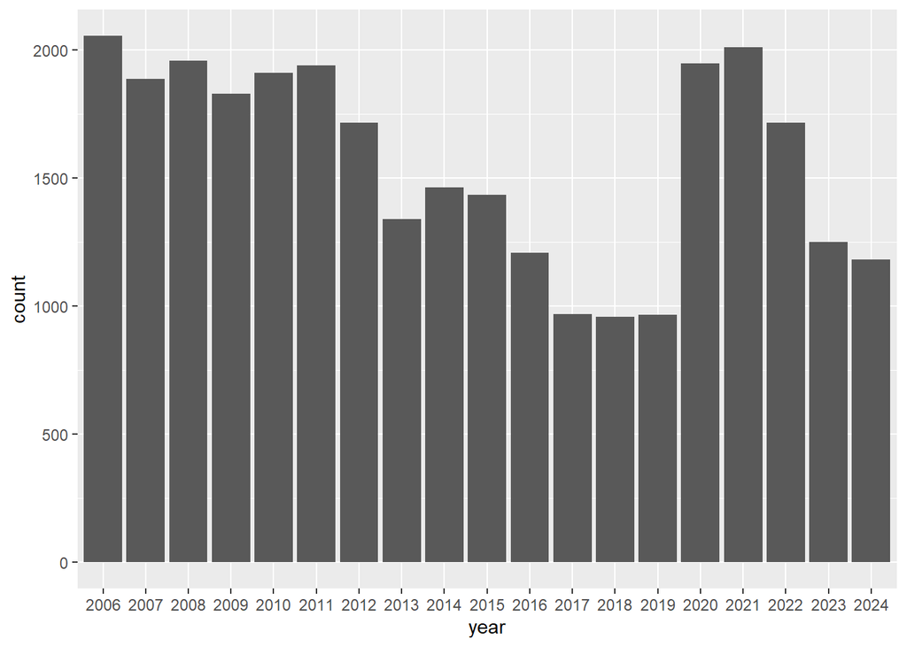

```r
# big change in 2020
shooting_trans %>%
  ggplot(aes(x = year)) +
  geom_histogram(stat = "count")
```

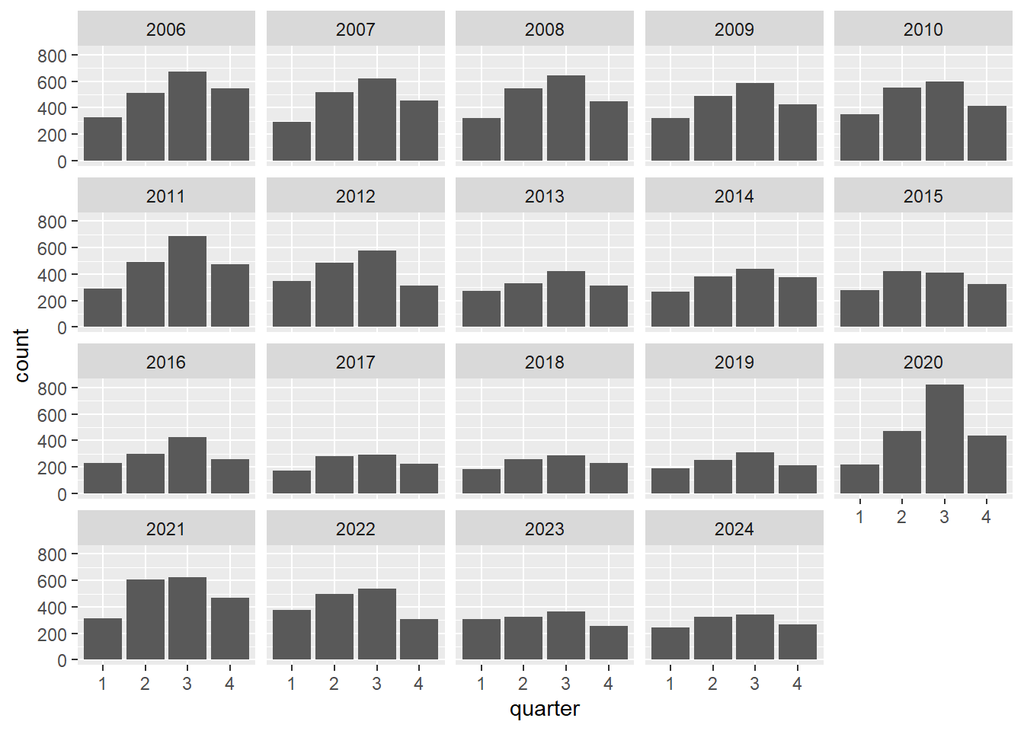

```r
# Q3 uptick almost every year, but maybe not quarterly after looking at month below
shooting_trans %>%
  ggplot(aes(x = quarter)) +
  geom_histogram(stat = "count") +
  facet_wrap(~ year)
```

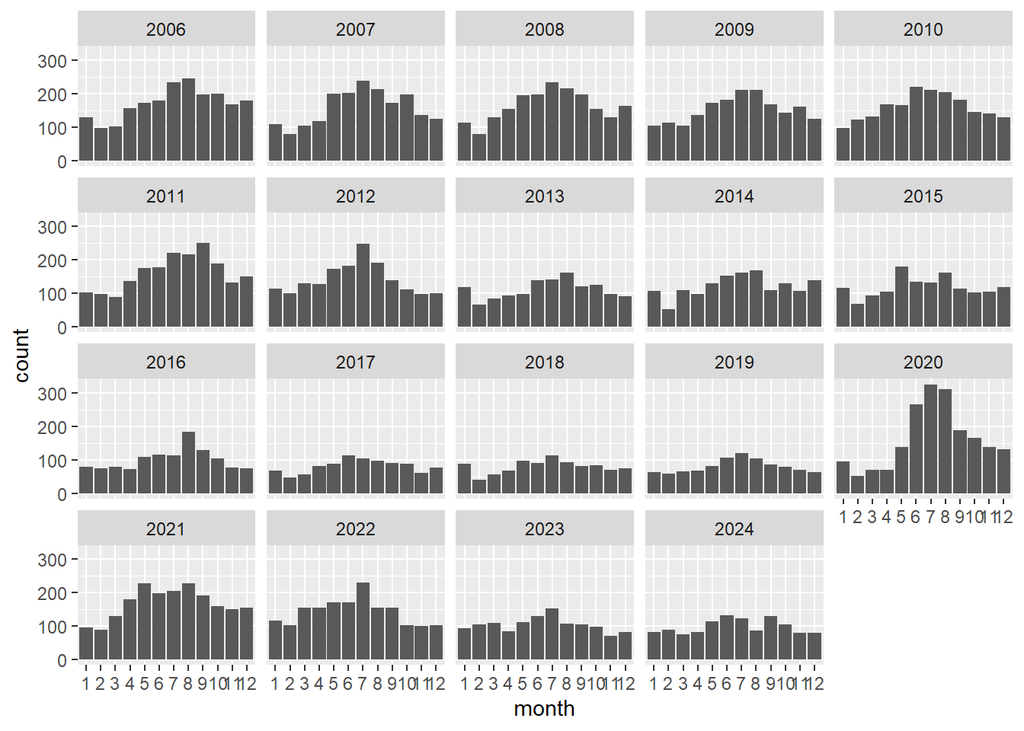

```r
shooting_trans %>%
  ggplot(aes(x = month)) +
  geom_histogram(stat = "count") +
  facet_wrap(~ year)
```

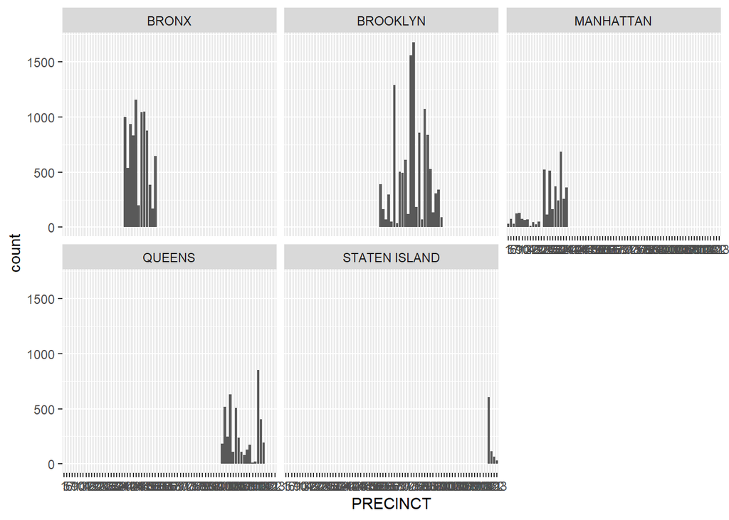

```r
shooting_trans %>%
  ggplot(aes(x = PRECINCT)) +
  geom_histogram(stat = "count") +
  facet_wrap(~ BORO)
```

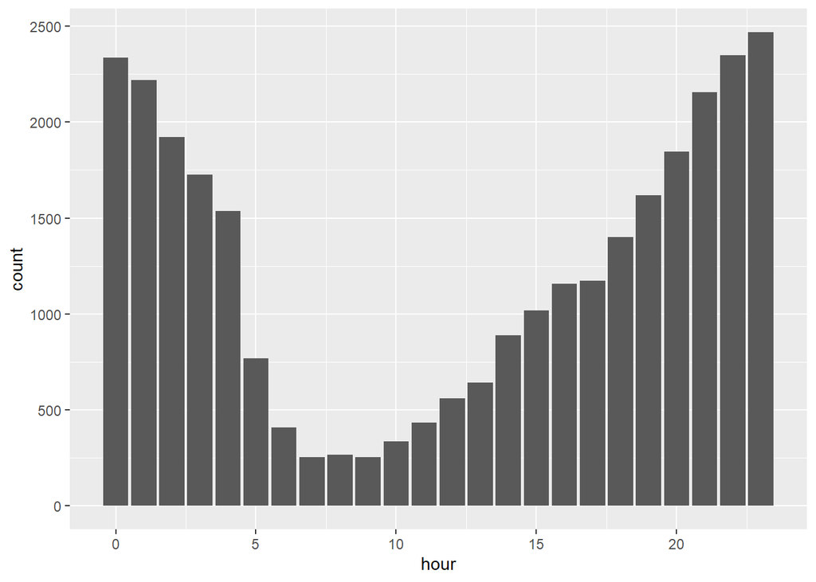

```r
shooting_trans %>%
  ggplot(aes(x = hour)) +
  geom_histogram(stat = "count")
```

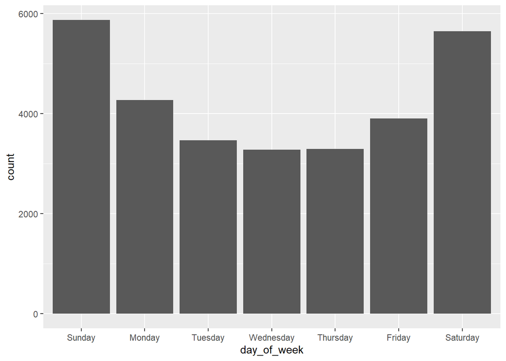

```r
shooting_trans %>%
  ggplot(aes(x = day_of_week)) +
  geom_histogram(stat = "count")
```

# Model the Data

I attempted a very basic linear model in hopes of answering the question: Given a day of the week, an hour of the day and the borough, could we help predict shooting activity? With an goal towards an application for police staffing optimization.

Model results and visualizations are outlined below.

```r
# Model -------------------------------------------------------------

# summarise data by date, hour and precinct
# hopes to predict shooting counts by date /time / borough for police staffing
shooting_trans_grp <- shooting_trans %>%
  group_by(hour, day_of_week, year, PRECINCT, BORO) %>%
  summarise(shooting_cnt = n(),
            murder_cnt = sum(STATISTICAL_MURDER_FLAG)) %>%
  ungroup()


mod <- lm(shooting_cnt ~ hour:day_of_week + day_of_week + hour + BORO+ year,
          data = shooting_trans_grp)


summary(mod)
```

```
##
## Call:
## lm(formula = shooting_cnt ~ hour:day_of_week + day_of_week +
##     hour + BORO + year, data = shooting_trans_grp)
##
## Residuals:
##     Min      1Q  Median      3Q     Max
## -0.9306 -0.5217 -0.3943  0.3413 19.4513
##
## Coefficients:
##                            Estimate Std. Error t value Pr(>|t|)
## (Intercept)                1.914661   0.041546  46.086  < 2e-16 ***
## day_of_weekMonday         -0.307361   0.048211  -6.375 1.87e-10 ***
## day_of_weekTuesday        -0.412676   0.049659  -8.310  < 2e-16 ***
## day_of_weekWednesday      -0.398569   0.053164  -7.497 6.80e-14 ***
## day_of_weekThursday       -0.466650   0.051890  -8.993  < 2e-16 ***
## day_of_weekFriday         -0.389281   0.048928  -7.956 1.87e-15 ***
## day_of_weekSaturday       -0.067719   0.039756  -1.703 0.088511 .
## hour                      -0.014900   0.002121  -7.025 2.21e-12 ***
## BOROBROOKLYN              -0.102880   0.018785  -5.477 4.38e-08 ***
## BOROMANHATTAN             -0.157234   0.024869  -6.322 2.63e-10 ***
## BOROQUEENS                -0.173123   0.023956  -7.227 5.12e-13 ***
## BOROSTATEN ISLAND         -0.191195   0.046132  -4.145 3.42e-05 ***
## year2007                   0.015979   0.043100   0.371 0.710829
## year2008                  -0.032648   0.042290  -0.772 0.440119
## year2009                  -0.022673   0.043225  -0.525 0.599905
## year2010                  -0.034775   0.042595  -0.816 0.414275
## year2011                  -0.024461   0.042516  -0.575 0.565079
## year2012                  -0.068426   0.043578  -1.570 0.116387
## year2013                  -0.182818   0.045643  -4.005 6.21e-05 ***
## year2014                  -0.159236   0.044751  -3.558 0.000374 ***
## year2015                  -0.168023   0.044891  -3.743 0.000182 ***
## year2016                  -0.222595   0.046574  -4.779 1.77e-06 ***
## year2017                  -0.220792   0.049883  -4.426 9.64e-06 ***
## year2018                  -0.192524   0.050462  -3.815 0.000136 ***
## year2019                  -0.207000   0.050076  -4.134 3.58e-05 ***
## year2020                  -0.066750   0.042062  -1.587 0.112536
## year2021                  -0.064249   0.041769  -1.538 0.124014
## year2022                  -0.068914   0.043513  -1.584 0.113267
## year2023                  -0.171341   0.046700  -3.669 0.000244 ***
## year2024                  -0.148706   0.047750  -3.114 0.001846 **
## hour:day_of_weekMonday     0.020530   0.003306   6.210 5.42e-10 ***
## hour:day_of_weekTuesday    0.022325   0.003403   6.560 5.52e-11 ***
## hour:day_of_weekWednesday  0.020913   0.003560   5.875 4.29e-09 ***
## hour:day_of_weekThursday   0.025574   0.003499   7.309 2.79e-13 ***
## hour:day_of_weekFriday     0.021424   0.003309   6.474 9.77e-11 ***
## hour:day_of_weekSaturday   0.006769   0.002988   2.265 0.023509 *
## ---
## Signif. codes:  0 '***' 0.001 '**' 0.01 '*' 0.05 '.' 0.1 ' ' 1
##
## Residual standard error: 1.072 on 20010 degrees of freedom
## Multiple R-squared:  0.01856,    Adjusted R-squared:  0.01684
## F-statistic: 10.81 on 35 and 20010 DF,  p-value: < 2.2e-16
```

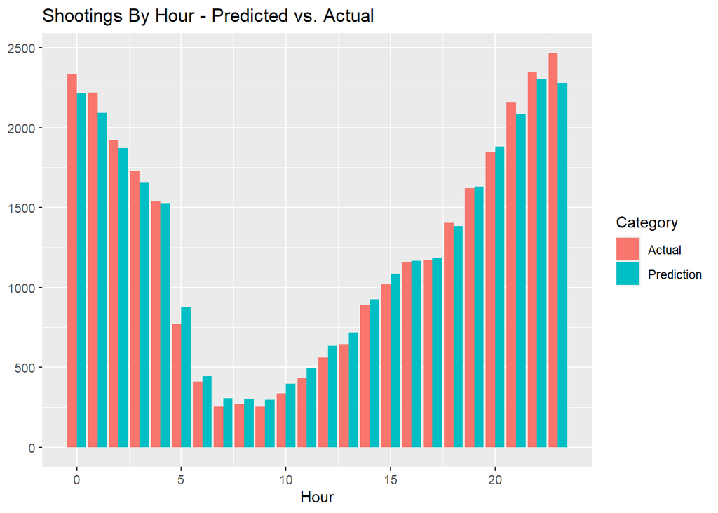

```r
shooting_trans_grp <- shooting_trans_grp %>%
  mutate(pred = predict(mod))


shooting_trans_grp %>%
  group_by(hour) %>%
  summarise(Actual = sum(shooting_cnt),
            Prediction = sum(pred)) %>%
  ungroup() %>%
  pivot_longer(cols = c(Actual, Prediction)) %>%
  rename(Category = name,
         Hour = hour) %>%
  ggplot(aes(fill=Category, y=value, x=Hour)) +
  geom_bar(position="dodge", stat="identity") +
  labs(title = "Shootings By Hour - Predicted vs. Actual", y = NULL)
```

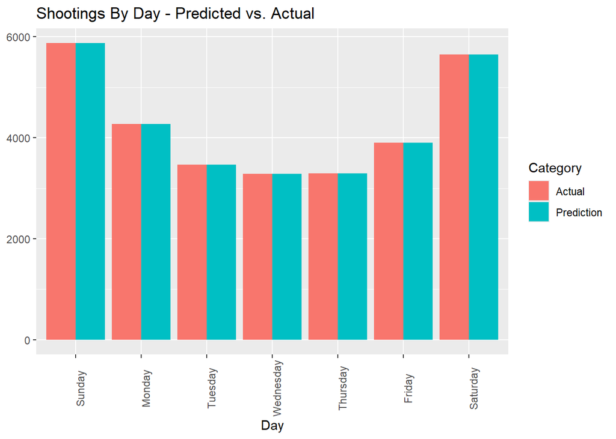

```r
shooting_trans_grp %>%
  group_by(day_of_week) %>%
  summarise(Actual = sum(shooting_cnt),
            Prediction = sum(pred)) %>%
  ungroup() %>%
  pivot_longer(cols = c(Actual, Prediction)) %>%
  rename(Category = name,
         Day = day_of_week) %>%
  ggplot(aes(fill=Category, y=value, x=Day)) +
  geom_bar(position="dodge", stat="identity") +
  labs(title = "Shootings By Day - Predicted vs. Actual", y = NULL) +
  theme(axis.text.x = element_text(angle = 90))
```

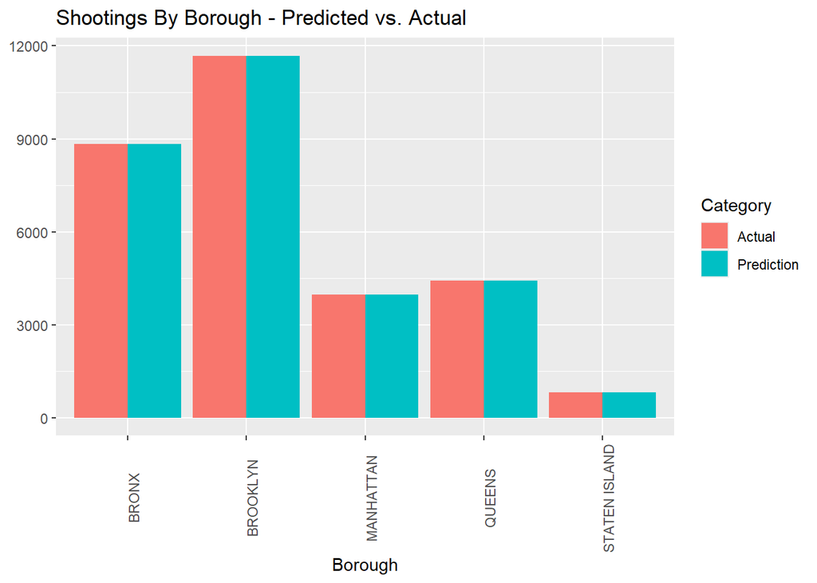

```r
shooting_trans_grp %>%
  group_by(BORO) %>%
  summarise(Actual = sum(shooting_cnt),
            Prediction = sum(pred)) %>%
  ungroup() %>%
  pivot_longer(cols = c(Actual, Prediction)) %>%
  rename(Category = name,
         Borough = BORO) %>%
  ggplot(aes(fill=Category, y=value, x=Borough)) +
  geom_bar(position="dodge", stat="identity") +
  labs(title = "Shootings By Borough - Predicted vs. Actual", y = NULL) +
  theme(axis.text.x = element_text(angle = 90))
```

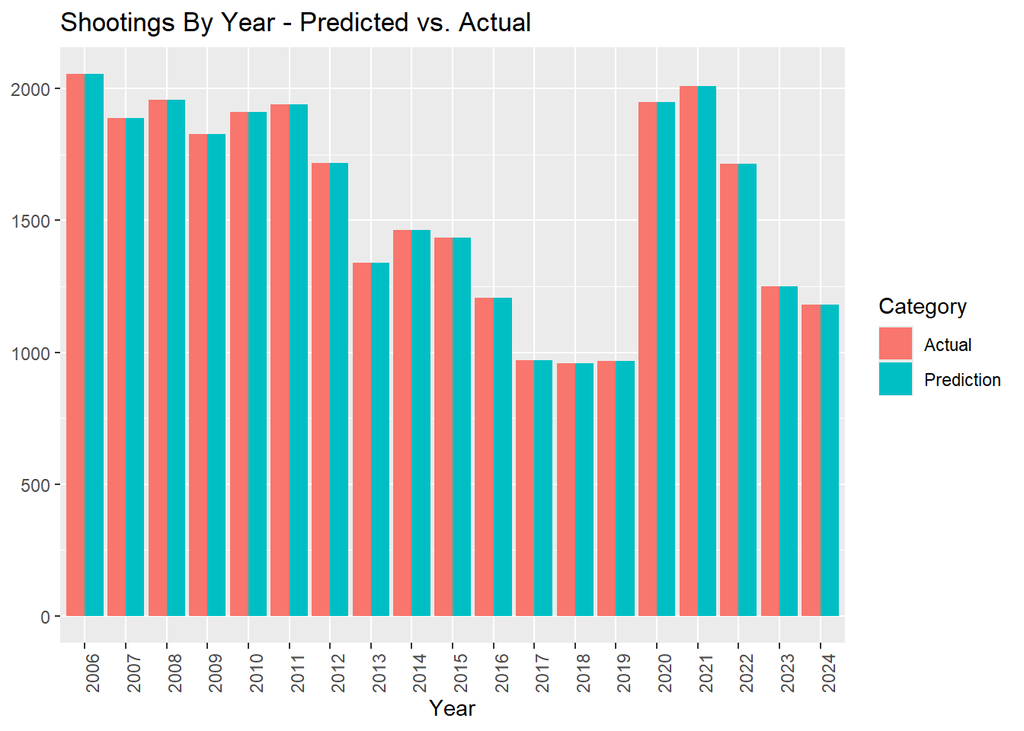

```r
shooting_trans_grp %>%
  group_by(year) %>%
  summarise(Actual = sum(shooting_cnt),
            Prediction = sum(pred)) %>%
  ungroup() %>%
  pivot_longer(cols = c(Actual, Prediction)) %>%
  rename(Category = name,
         Year = year) %>%
  ggplot(aes(fill=Category, y=value, x=Year)) +
  geom_bar(position="dodge", stat="identity") +
  labs(title = "Shootings By Year - Predicted vs. Actual", y = NULL) +
  theme(axis.text.x = element_text(angle = 90))
```

# Potential Bias

A potential bias I have was in variable selection. I really only modeled the variables that made logical sense to me from my experience (e.g., more shootings happen on weekends or late at night) and supported by my introductory analysis / visualizations. I am sure given more time I could really look into any/all of the variables and see if there was something additional of note that I missed.

I also skipped over some variables that seemed to potentially have a correlation as I wasn’t sure how to explain them or what use they would be as an answer to my question and goal of helping Police staffing. E.g., the age group of the victim seemed related, but I couldn’t see how that would help anyone prior to a crime being committed, so I didn’t want to use it as a predictor and leaving that information out could have skewed my results.

# Conclusion

Thank you for reviewing my report!